# 621-Final Project

### Grow Tree

```r
# grow tree
m1 <- rpart(target ~ .,  data = train_all, method = 'anova')
m1
```

```
## n= 20998
##
## node), split, n, deviance, yval
##       * denotes terminal node
##
## 1) root 20998 3640.8070 1.223212
##   2) PAY_0< 1.5 18789 2619.2390 1.167438
##     4) PAY_2< 1.5 17205 2127.5020 1.144551 *
##     5) PAY_2>=1.5 1584  384.8327 1.416035 *
##   3) PAY_0>=1.5 2209  465.9973 1.697601 *
```

#### Plot and summarize

```
##
## Regression tree:
## rpart(formula = target ~ ., data = train_all, method = "anova")
##
## Variables actually used in tree construction:
## [1] PAY_0 PAY_2
##
## Root node error: 3640.8/20998 = 0.17339
##
## n= 20998
##
##         CP nsplit rel error  xerror      xstd
## 1 0.152595      0   1.00000 1.00007 0.0091751
## 2 0.029363      1   0.84740 0.84753 0.0096794
## 3 0.010000      2   0.81804 0.81824 0.0094815
```

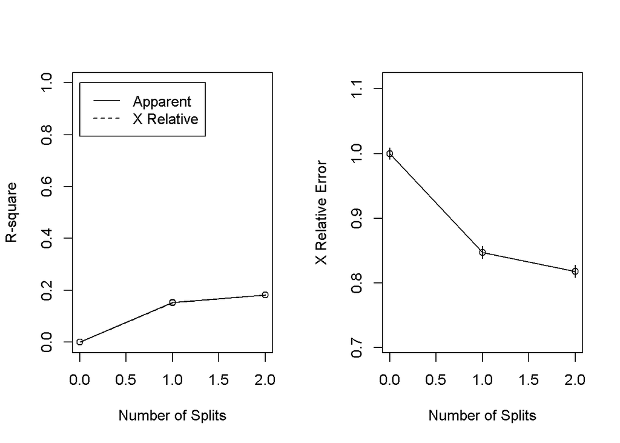

```r
# additional plots
par(mfrow=c(1,2))
rsq.rpart(m1)
```

The relative error is $1-R^2$, similar to linear regression. The xerror is related to the [PRESS](https://en.wikipedia.org/wiki/PRESS_statistic) statistic. The split from 0 to 1 appears to have the largest improvement of fit. The split from 1 to 2 is much less of an improvement.

The figure to the left shows a visual of the aforementioned first split providing more information than the second split. The figure to the right shows if a tree should be pruned, and in our case it does not.

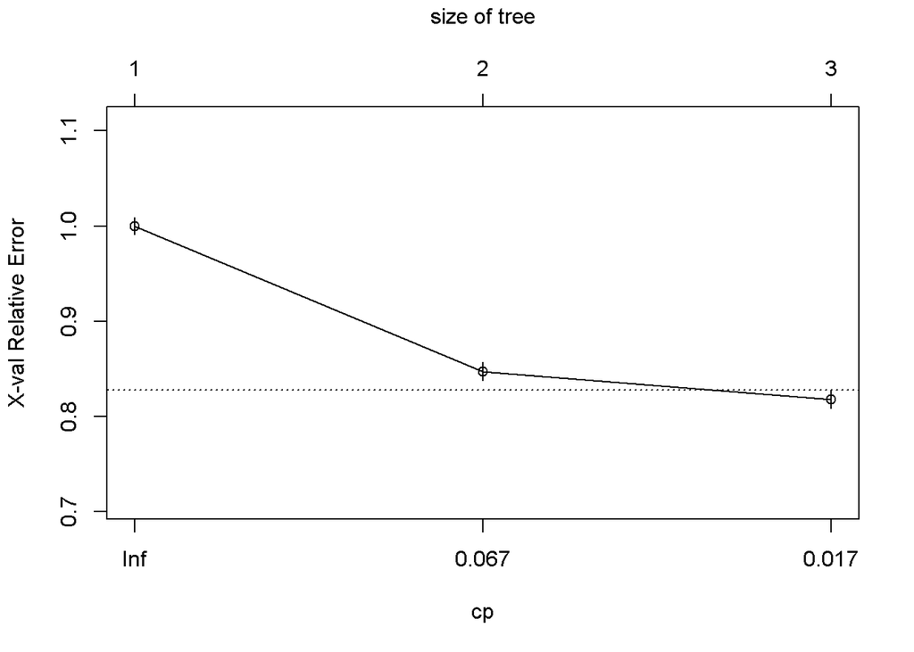

```r
plotcp(m1) # visualize cross-validation results
```

Looking at the `plotcp` function we can take a look and see if the tree needs pruning, and we can see 3 nodes appears to be the ideal size.

```r
summary(m1, cp = 0.1) # detailed summary of splits
```

```
## Call:
## rpart(formula = target ~ ., data = train_all, method = "anova")
##   n= 20998
##
##           CP nsplit rel error    xerror        xstd
## 1 0.15259545      0 1.0000000 1.0000681 0.009175056
## 2 0.02936285      1 0.8474046 0.8475288 0.009679359
## 3 0.01000000      2 0.8180417 0.8182446 0.009481548
##
## Variable importance
## PAY_0 PAY_2 PAY_5 PAY_4 PAY_3 PAY_6
##    72    16     4     3     3     2
##
## Node number 1: 20998 observations,    complexity param=0.1525954
##   mean=1.223212, MSE=0.1733883
##   left son=2 (18789 obs) right son=3 (2209 obs)
##   Primary splits:
##       PAY_0 < 1.5 to the left,  improve=0.15259540, (0 missing)
##       PAY_2 < 1.5 to the left,  improve=0.11423520, (0 missing)
##       PAY_3 < 1.5 to the left,  improve=0.08684393, (0 missing)
##       PAY_4 < 1.5 to the left,  improve=0.07681243, (0 missing)
##       PAY_5 < 1   to the left,  improve=0.06983654, (0 missing)
##   Surrogate splits:
##       PAY_5 < 2.5 to the left,  agree=0.900, adj=0.048, (0 split)
##       PAY_4 < 2.5 to the left,  agree=0.900, adj=0.045, (0 split)
##       PAY_6 < 2.5 to the left,  agree=0.898, adj=0.032, (0 split)
##       PAY_3 < 2.5 to the left,  agree=0.898, adj=0.031, (0 split)
##       PAY_2 < 2.5 to the left,  agree=0.898, adj=0.027, (0 split)
##
## Node number 2: 18789 observations
##   mean=1.167438, MSE=0.1394028
##
## Node number 3: 2209 observations
##   mean=1.697601, MSE=0.210954
```

```r
# Mike - this plot throws an error "need finite ylim"



#plot(predict(m1), resid(m1))
#temp <- m1$frame[m1$frame$var == '<leaf>',]
#axis(3, at = temp$yval, as.character(row.names(temp)))
#mtext('leaf number', side = 3, line = 3)
#abline(h = 0, lty = 2)
```

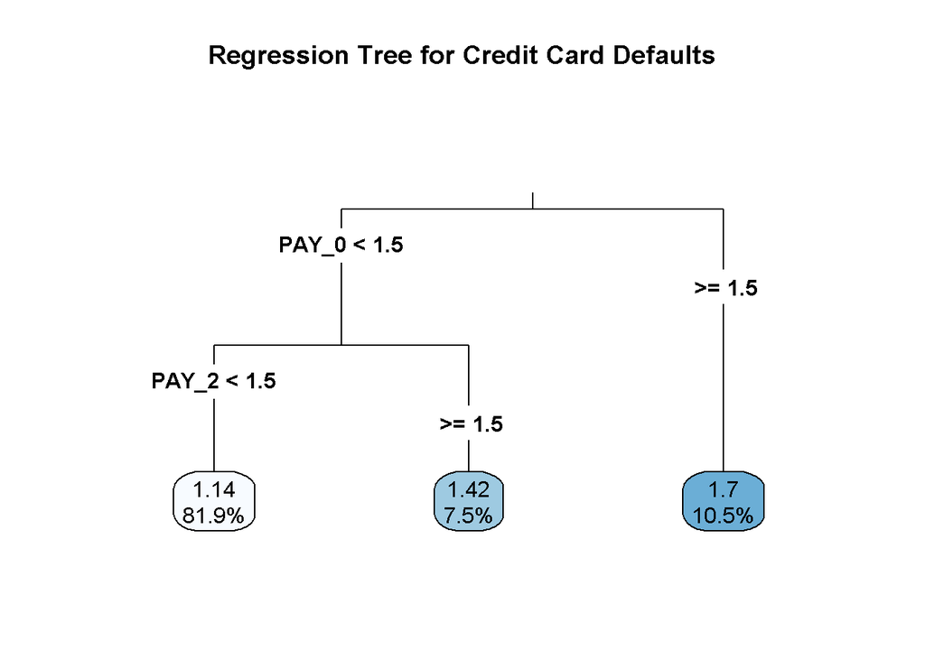

```r
rpart.plot(m1, type=3, digits=3, fallen.leaves=TRUE, main='Regression Tree for Credit Card Defaults')
```

Lastly in the plotting section is a visual of the regression tree. The model tells us that if $PAY_-0\geq 1.5$, there is a 69.8% chance the customer will default. Approx 10.5% of the data set falls under this threshold. On the other hand if $PAY_-0< 1.5$, the model takes a look at the customers $`PAY_-2$ scores. If $PAY_-2\geq1.5$ there is a 41.6% chance the customer will default, which comprises of 7.5% of the dataset. Lastly if $PAY_-2<1.5$ there is only a 14.5% chacne of default, which 81.9% of the data set falls under.

### Predict

```r
p1 <- predict(m1, test_all)

#confMat <- table(test_data$target, p1)
#accuracy <- sum(diag(confMat))/sum(confMat)
#accuracy
#
#mse(test_data$target, p1)
#rmse(test_data$target, p1)
#mae(test_data$target, p1)
#se(test_data$target, p1)
```

# Nueral Network

A Nueral Netowrk model was used to fit the credit card dataset. A nueral network processes the data on several levels.The first layer of the neural network receives the predictor variables which are processed and passed to the hidden layer. The hidden layer passes the processed predictor values to the last layer where the output is produced

A nueral network model was chosen to predict default based on its ability to learn form the information provided.

## Data Preprocessing

As neural networks use activation functions between -1 and +1 - the variables were scaled down. This is done to prevent the neural network from spend training iterations doing the scaling.

Min-max normalziation was used to transform the data into a common range.This removes the scaling effect from all the variables.

The normalzied data returns a matrix that was converted to a dataframe so that the neural network model can be computed.

```
##   LIMIT_BAL SEX EDUCATION MARRIAGE AGE PAY_0 PAY_2 PAY_3 PAY_4 PAY_5 PAY_6
## 1     20000   2         2        1  24     2     2    -1    -1    -2    -2
## 2    120000   2         2        2  26    -1     2     0     0     0     2
##   BILL_AMT1 BILL_AMT2 BILL_AMT3 BILL_AMT4 BILL_AMT5 BILL_AMT6 PAY_AMT1
## 1      3913      3102       689         0         0         0        0
## 2      2682      1725      2682      3272      3455      3261        0
##   PAY_AMT2 PAY_AMT3 PAY_AMT4 PAY_AMT5 PAY_AMT6 DEFAULT MARRIED MALE
## 1      689        0        0        0        0       1       1    0
## 2     1000     1000     1000        0     2000       1       0    0
##   EDU_COLLEGE EDU_ADV_DEGREE
## 1           1              0
## 2           1              0
```

| LIMIT_BAL | SEX | EDUCATION | MARRIAGE | AGE | PAY_0 | PAY_2 | PAY_3 | PAY_4 | PAY_5 | PAY_6 | BILL_AMT1 | BILL_AMT2 | BILL_AMT3 | BILL_AMT4 | BILL_AMT5 | BILL_AMT6 | PAY_AMT1 | PAY_AMT2 | PAY_AMT3 | PAY_AMT4 | PAY_AMT5 | PAY_AMT6 | DEFAULT | MARRIED | MALE | EDU_COLLEGE | EDU_ADV_DEGREE |
| --- | --- | --- | --- | --- | --- | --- | --- | --- | --- | --- | --- | --- | --- | --- | --- | --- | --- | --- | --- | --- | --- | --- | --- | --- | --- | --- | --- |
| 20000 | 2 | 2 | 1 | 24 | 2 | 2 | -1 | -1 | -2 | -2 | 3913 | 3102 | 689 | 0 | 0 | 0 | 0 | 689 | 0 | 0 | 0 | 0 | 1 | 1 | 0 | 1 | 0 |
| 120000 | 2 | 2 | 2 | 26 | -1 | 2 | 0 | 0 | 0 | 2 | 2682 | 1725 | 2682 | 3272 | 3455 | 3261 | 0 | 1000 | 1000 | 1000 | 0 | 2000 | 1 | 0 | 0 | 1 | 0 |

```
## target ~ LIMIT_BAL + AGE + PAY_0 + PAY_2 + PAY_3 + PAY_4 + PAY_5 +
##     PAY_6 + PAY_AMT1 + PAY_AMT2 + PAY_AMT3 + PAY_AMT4 + PAY_AMT5 +
##     PAY_AMT6 + MARRIED + MALE + EDU_COLLEGE + EDU_ADV_DEGREE +
##     AVG_BILL + AVG_BILL_TO_LIMIT + PAY_TO_BILL + INC_COUNT
```

## Nueral Network Matrix

[output not shown]

```r
DataPred <- neuralnet::compute(neuralModel, test_nn[, -1])

#DataPred$net.result

#translate probabilities to predictions -->
# KF: Not sure this is the correct to get probability .  Compure returns a

nn_predict <- rep(0,nrow(test_nn))
nn_predict[DataPred$net.result>.5] <- 1
#confusion matrix
table(pred=nn_predict,true=test_nn$target)
```

```
##     true
## pred    0    1
##    0 6999 1891
##    1   52   58
```

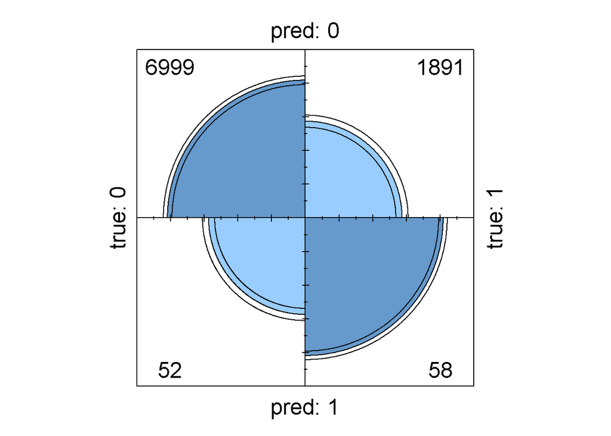

```r
fourfoldplot(table(pred=nn_predict,true=test_nn$target))
```

```r
#accuracy
mean(nn_predict==test_nn$target)
```

```
## [1] 0.7841111111
```

# References

https://datascienceplus.com/fitting-neural-network-in-r/ https://www.youtube.com/watch?v=LTg-qP9iGFY https://www.analyticsvidhya.com/blog/2017/09/creating-visualizing-neural-network-in-r/

# https://stats.stackexchange.com/questions/21717/how-to-train-and-validate-a-neural-network-model-in-r

```r
c.fit <- train(as.factor(target) ~ ., data = train_nn,
         method = "nnet", maxit = 1,   #increase later since this takes times to run
         trace = F)


nnet.predict <- predict(c.fit, newdata = test_nn[,-23], type='raw')
#prestige.rmse <- sqrt(mean((prestige.predict - prestige.test$income)^2)

confusionMatrix(nnet.predict, as.factor(test_nn[,23]))
```

```
## Confusion Matrix and Statistics
##
##           Reference
## Prediction    0    1
##          0 7051 1949
##          1    0    0
##
##                Accuracy : 0.7834444
##                  95% CI : (0.7747881, 0.7919169)
##     No Information Rate : 0.7834444
##     P-Value [Acc > NIR] : 0.5060689
##
##                   Kappa : 0
##  Mcnemar's Test P-Value : < 0.00000000000000022
##
##             Sensitivity : 1.0000000
##             Specificity : 0.0000000
##          Pos Pred Value : 0.7834444
##          Neg Pred Value :       NaN
##              Prevalence : 0.7834444
##          Detection Rate : 0.7834444
##    Detection Prevalence : 1.0000000
##       Balanced Accuracy : 0.5000000
##
##        'Positive' Class : 0
##
```

```r
getTrainPerf(c.fit)
```

| TrainAccuracy | TrainKappa | method |
| --- | --- | --- |
| 0.7767899619 | 0 | nnet |

## Metrics

http://blog.revolutionanalytics.com/2016/03/com_class_eval_metrics_r.html